# chp_9_plots

```python
import numpy as np
import matplotlib.pyplot as plt
import pandas as pd
```

```python
%matplotlib inline
```

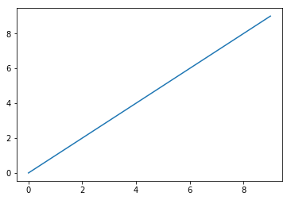

```python
plt.plot(np.arange(10));
```

## Figures and Subplots

```python
fig = plt.figure()
```

> `figsize` gaurantees the figure with have a size and aspect ratio

You can't make a plot with a blank `Figure`, you have to create one or more `subplots`

```python
ax1 = fig.add_subplot(2, 2, 1)
```

This means the figure should be `2 x 2` and we are selecting the first of 4 subplots

```python
ax2 = fig.add_subplot(2, 2, 2)
ax3 = fig.add_subplot(2, 2, 3)
```

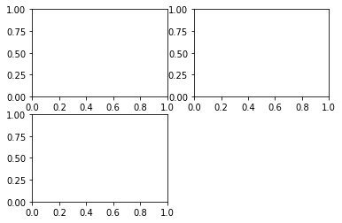

```python
fig
```

Issuing a plotting command will draw on the last figure and subplot used (apparently, but not in this notebook)

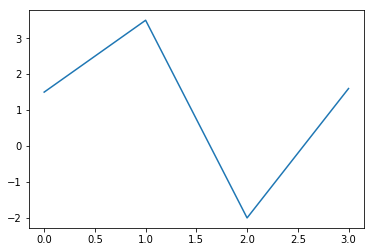

```python
plt.plot([1.5, 3.5, -2, 1.6]);
```

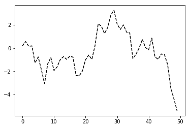

```python
plt.plot(np.random.randn(50).cumsum(), 'k--');
```

The `k--` parameter is a *style* option telling matplotlib to print a dashed line

The object returned is a `AxesSubPlot` which you can plot on a subplot using it's instance methods

```python
_ = ax1.hist(np.random.randn(100), bins=20, color='k', alpha=0.3)
```

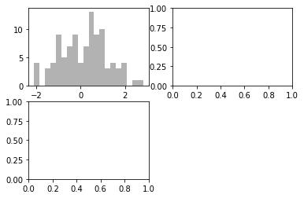

```python
fig
```

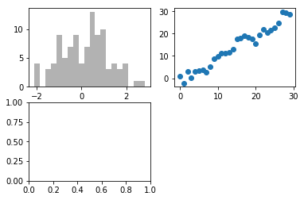

```python
ax2.scatter(np.arange(30), np.arange(30) + 3 * np.random.randn(30))
fig
```

Since creating subplots is such a common task, there is a convenient method `plt.sublots` that creates a new figure and returns the subplot objects

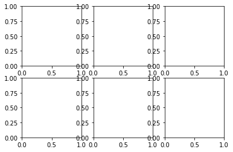

```python
fig, axes = plt.subplots(2, 3)
```

Axes are indexed just like a two dimensional array

```python
axes[0, 1]
```

### Adjusting Spaces around Subplots

By default matplotlib adds space around plots relative to height and width of the subplots. It can be adjusted with `subplots_adjust`

```
subplots_adjust(left=None, botttom=None, right=None, top=None, wspace=None, hspace=None)
```

`wspace` and `hspace` control the percentage of the figure to be used for spacing

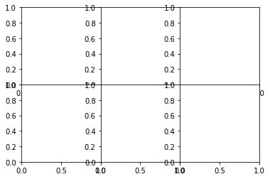

```python
fig.subplots_adjust(wspace=0, hspace=0)
fig
```

There is some overlapping of labels, which matplot does not fix for you, you must must fix there sourself.

### Colours, Markers and Line Styles

the `plot` function accepts arrays of x and y coordinates and optional kwargs for colour and line style

```
ax.plot(x, y, 'k--')
```

More explicitly

```
ax.plot(x, y, linestyle='--', color='g')
```

Color can also be a `hex` RGB colour

Line plots have *markers* to indicate the data points, sometimes it is unclear where the points lie.

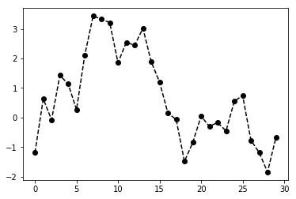

```python
plt.plot(np.random.randn(30).cumsum(), 'ko--');
```

More explicitly (and explicit is better than implicit)

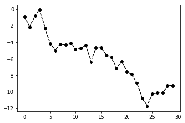

```python
plt.plot(np.random.randn(30).cumsum(), color='k', linestyle='dashed', marker='o');
```

You can draw the line in a different way:

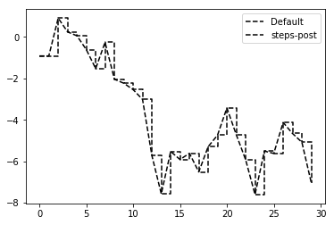

```python
data = np.random.randn(30).cumsum()
plt.plot(data, 'k--', label='Default')
plt.plot(data, 'k--', drawstyle='steps-post', label='steps-post')
plt.legend(loc='best');
```

### Ticks, Labels and Legends

There are 2 ways to plot:

- the procedural `pyplot` interface
- the object oriented native matplotlib API

The `pyplot` interface has methods `xlim`, `xticks` and `xticklabels`. These control plot range, tick locations and tick labels.

`plt.xlim()` returns the current x axis plotting range. Called with parameters, sets the range: `plt.xlim([0, 10])`

The corresponding api methods are `ax.get_xlim` and `ax.get_ylim`

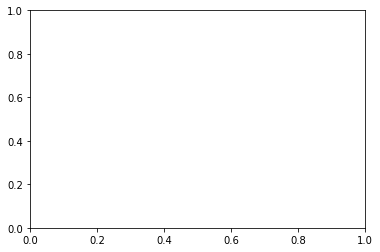

```python
fig = plt.figure(); ax = fig.add_subplot(1, 1, 1)
```

[figure not shown]

```python
ax.plot(np.random.randn(1000).cumsum())
fig
```

`set_xticks` tells matplotlib where to place the ticks on the x axis. `set_xticklabels` sets the labels.

```python
ticks = ax.set_xticks([0, 250, 500, 750, 1000])
labels = ax.set_xticklabels(['one', 'two', 'three', 'four', 'five'], rotation=30, fontsize='small')
```

`set_title` sets teh title of the subplot. `set_xlabels` sets the label for the x axis.

[figure not shown]

```python
ax.set_title('My First Matplot Plot')
ax.set_xlabel('Stages')
fig
```

#### Adding Legends

The easiest thing to do is set the label of each part of the plot

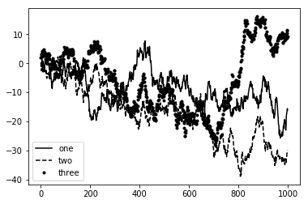

```python
fig = plt.figure(); ax = fig.add_subplot(1, 1, 1)
ax.plot(np.random.randn(1000).cumsum(), 'k', label='one')
ax.plot(np.random.randn(1000).cumsum(), 'k--', label='two')
ax.plot(np.random.randn(1000).cumsum(), 'k.', label='three')
ax.legend(loc='best');
```

You can use `ax.legend()` or `plt.legend()` to add the legend. The kwarg `loc` tells where to put the legend (`best` is a good choice). To exlcude from the legend, you can set `label='__no_legend__'`

### Annotations

Text, arrows and other shapes. Using teh `text`, `arrow` and `annotate` functions

```python
from datetime import datetime
data = pd.read_csv('spx.csv', index_col=0, parse_dates=True)
data.head()
```

|  | SPX |
| --- | --- |
| 1990-02-01 | 328.79 |
| 1990-02-02 | 330.92 |
| 1990-02-05 | 331.85 |
| 1990-02-06 | 329.66 |
| 1990-02-07 | 333.75 |

```python
spx = data['SPX']
```

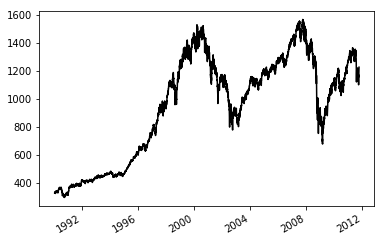

```python
fig = plt.figure(); ax = fig.add_subplot(1, 1, 1)
spx.plot(ax=ax, style='k-');
```

```python
crisis_data = [
    (datetime(2007, 10, 11), 'Peak of the Bull Market'),
    (datetime(2008, 3, 12), 'Bear Sterns Fails'),
    (datetime(2008, 9, 15), 'Lehman Bankrupcy')
]
```

```python
for date, label in crisis_data:
    ax.annotate(label, xy=(date, spx.asof(date) + 50), xytext=(date, spx.asof(date) + 200),
               arrowprops=dict(facecolor='black'), horizontalalignment='left', verticalalignment='top')
```

```python
# Zoom in on 2007 - 2010
ax.set_xlim(['1/1/2007', '1/1/2011'])
ax.set_ylim([600, 1800])
```

```
(600, 1800)
```

```python
ax.set_title('Important dates in 2008-2009 financial crisis')
```

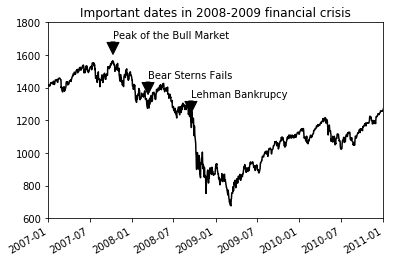

```python
fig
```

Drawing shapes requires more care, `matplotlib` has objects that represent many common shapes, reffered to as *patches*. Some like `Rectangle` and `Circle` are found in `matplotlib.pyplot`, the full set is located in `matplotlib.patches`

Adding a shape to a plot, you create the patch object `shp` and add it to the subplot by calling `ax.add_patch(shp)`

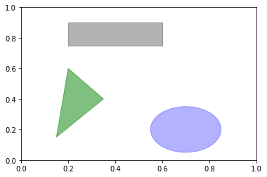

```python
fig = plt.figure(); ax = fig.add_subplot(1, 1, 1);
rect = plt.Rectangle((0.2, 0.75), 0.4, 0.15, color='k', alpha=0.3)
circ = plt.Circle((0.7, 0.2), 0.15, color='b', alpha=0.3)
pgon = plt.Polygon([[0.15, 0.15], [0.35, 0.4], [0.2, 0.6]], color='g', alpha=0.5)
ax.add_patch(rect)
ax.add_patch(circ)
ax.add_patch(pgon);
```

### Saving Plots to File

The active figure can be saved with `plt.savefig`

To save an `svg`:

```python
fig.savefig('shapes.svg')
```

The file type is inferred from the file extensions

```python
fig.savefig('shapes.png', dpi=400, bbox_inches='tight')
```

`savefig` doesn't have to write to disk, it can also write to any file-like object such as `BytesIO`

```python
from io import BytesIO
buffer = BytesIO()
plt.savefig(buffer)
```

```python
plot_data = buffer.getvalue()
```

This is useful for serving dynamically-generated images over the web.

### Matplotlib Configuration

Has colour schemes and defaults geared towards publications. Nearly all of this behaviour can be customised. For example you can set a global figure size:

```python
plt.rc('figure', figsize=(10, 5))
```

The first argument to `rc` is the component you want to customise.

```python
font_options = {'family': 'monospace', 'weight': 'bold', 'size': 15}
plt.rc('font', **font_options)
```

There is matplotlibrc file in: `matplotlib/mpl-data` which you can put in yourt home directory and it will be loaded each time you run matplotlib.

## Plotting with Pandas and Seaborn

`matplotlib` can be fairly low level. You assemble the plot from it's base components: line, bar, box, scatter, legend, title, tick labels and others. Pandas has uilt-in methods which simplify visualisation creation.

[seaborn docs](https://seaborn.pydata.org/)

### Line Plots

Series and Dataframes have the `plot` function for basic plots

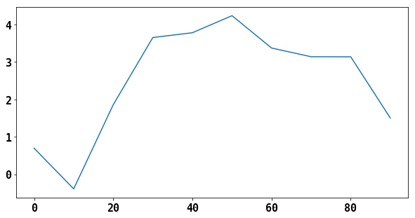

```python
s = pd.Series(np.random.randn(10).cumsum(), index = np.arange(0, 100, 10))
s.plot()
```

The series's index is set on the x-axis. You can exclude it using `use_index=False`. The ticks and limits can be adjusted using `xlim` and `xticks`

It accepts an `ax` attribute to send the plot to a specific `subplot` object

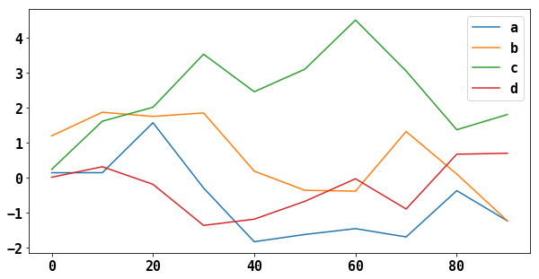

```python
df = pd.DataFrame(np.random.randn(10, 4).cumsum(0), columns=['a', 'b', 'c', 'd'], index=np.arange(0, 100, 10))
df.plot();
```

### Bar Plots

`plot.bar()` and `plot.barh()` make vertical and horizontal bar plots. In this case the index will be used as the x (bar) or y (barh) ticks

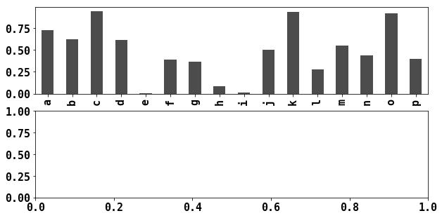

```python
fig, axes = plt.subplots(2, 1)
data = pd.Series(np.random.rand(16), index=list('abcdefghijklmnop'))
data.plot.bar(ax=axes[0], color='k', alpha=0.7)
```

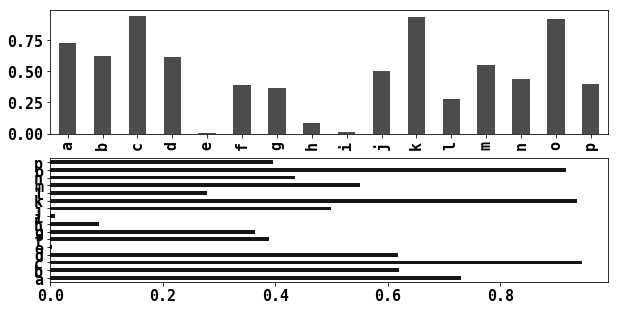

```python
data.plot.barh(ax=axes[1], color='k', alpha=0.7)
fig
```

With a DataFrame, group row values together

```python
df = pd.DataFrame(
    np.random.rand(6, 4),
    index=['one', 'two', 'three', 'four', 'five', 'six'],
    columns=pd.Index(['A', 'B', 'C', 'D'], name='Genus')
)
df
```

| Genus | A | B | C | D |
| --- | --- | --- | --- | --- |
| one | 0.291024 | 0.425924 | 0.832796 | 0.027127 |
| two | 0.680509 | 0.211131 | 0.971022 | 0.489830 |
| three | 0.751700 | 0.332034 | 0.621238 | 0.433753 |
| four | 0.832437 | 0.331309 | 0.959043 | 0.274794 |
| five | 0.976971 | 0.416167 | 0.960919 | 0.741820 |
| six | 0.248145 | 0.930182 | 0.927123 | 0.958313 |

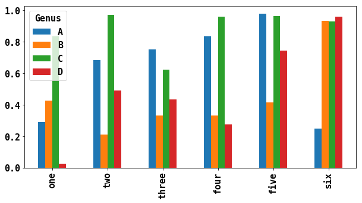

```python
df.plot.bar();
```

> Not the plot name, `Genus` is used as the title of the legend

Stacked bar plots are created by passing `stacked=True`, resulting in each row being stacked together

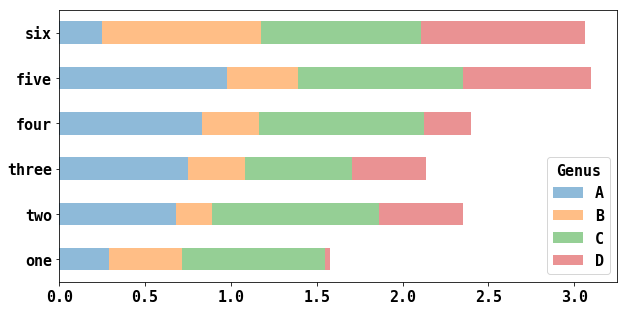

```python
df.plot.barh(stacked=True, alpha=0.5);
```

> A useful recipe for bar plots is to visualise a series's value frequency using: `s.value_counts().plot.bar()`

```python
tips = pd.read_csv('tips.csv')
tips.head()
```

|  | total_bill | tip | smoker | day | time | size |
| --- | --- | --- | --- | --- | --- | --- |
| 0 | 16.99 | 1.01 | No | Sun | Dinner | 2 |
| 1 | 10.34 | 1.66 | No | Sun | Dinner | 3 |
| 2 | 21.01 | 3.50 | No | Sun | Dinner | 3 |
| 3 | 23.68 | 3.31 | No | Sun | Dinner | 2 |
| 4 | 24.59 | 3.61 | No | Sun | Dinner | 4 |

```python
party_counts = pd.crosstab(tips['day'], tips['size'])
party_counts
```

| size day | 1 | 2 | 3 | 4 | 5 | 6 |
| --- | --- | --- | --- | --- | --- | --- |
| Fri | 1 | 16 | 1 | 1 | 0 | 0 |
| Sat | 2 | 53 | 18 | 13 | 1 | 0 |
| Sun | 0 | 39 | 15 | 18 | 3 | 1 |
| Thur | 1 | 48 | 4 | 5 | 1 | 3 |

There are not many 1 and 6 party tables. Normalise so each row sums to 1

```python
party_counts = party_counts.loc[:, 2:5]
```

```python
party_counts
```

| size day | 2 | 3 | 4 | 5 |
| --- | --- | --- | --- | --- |
| Fri | 16 | 1 | 1 | 0 |
| Sat | 53 | 18 | 13 | 1 |
| Sun | 39 | 15 | 18 | 3 |
| Thur | 48 | 4 | 5 | 1 |

```python
party_pcts = party_counts.div(party_counts.sum(1), axis=0)
party_pcts
```

| size day | 2 | 3 | 4 | 5 |
| --- | --- | --- | --- | --- |
| Fri | 0.888889 | 0.055556 | 0.055556 | 0.000000 |
| Sat | 0.623529 | 0.211765 | 0.152941 | 0.011765 |
| Sun | 0.520000 | 0.200000 | 0.240000 | 0.040000 |
| Thur | 0.827586 | 0.068966 | 0.086207 | 0.017241 |

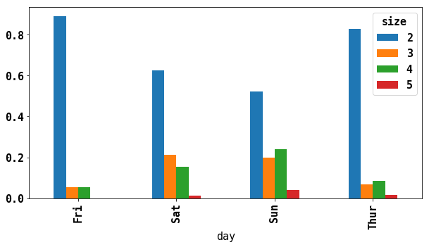

```python
party_pcts.plot.bar();
```

With data requiring aggregation and summarisation before making a plot, using the seaborn package can make things simpler.

```python
import seaborn as sns
# Adding a column
tips['tip_pct'] = tips['tip'] / (tips['total_bill'] - tips['tip'])
tips.head()
```

|  | total_bill | tip | smoker | day | time | size | tip_pct |
| --- | --- | --- | --- | --- | --- | --- | --- |
| 0 | 16.99 | 1.01 | No | Sun | Dinner | 2 | 0.063204 |
| 1 | 10.34 | 1.66 | No | Sun | Dinner | 3 | 0.191244 |
| 2 | 21.01 | 3.50 | No | Sun | Dinner | 3 | 0.199886 |
| 3 | 23.68 | 3.31 | No | Sun | Dinner | 2 | 0.162494 |
| 4 | 24.59 | 3.61 | No | Sun | Dinner | 4 | 0.172069 |

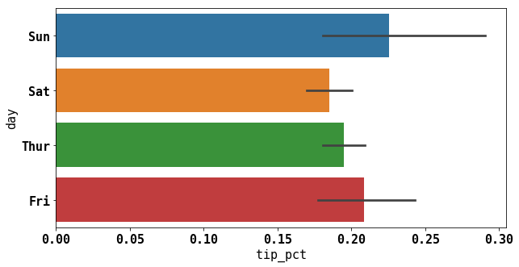

```python
sns.barplot(x='tip_pct', y='day', data=tips, orient='h');
```

Plotting in `seaborn` takes the `data` argument. The bloack lines represent the 95% confidence level.

seaborn has the `hue` option to split up against another categorical value:

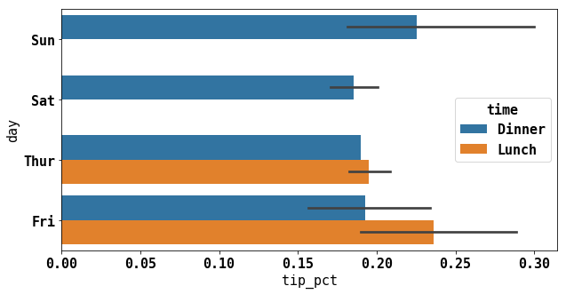

```python
sns.barplot(x='tip_pct', y='day', data=tips, hue='time', orient='h');
```

You can set different appearance attributes with `sns.set`

```python
sns.set(style='whitegrid')
```

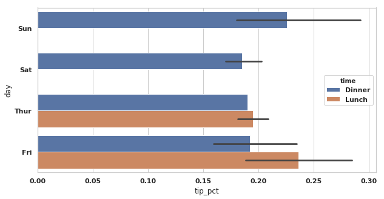

```python
sns.barplot(x='tip_pct', y='day', data=tips, hue='time', orient='h');
```